# 信用违约预测

#### 背景说明

风险已经成为了今年金融市场的重要主题之一，银行作为贷方，随时都面临着借贷者违约的风险。传统的专家规则在金融科技时代逐渐过时，机器学习和金融业务的交叉也延伸到信贷领域。违约预测就是其中一重要应用。本实验基于信贷业务场景中一个月内的抽样数据，数据集有34个维度，Target表示客户在接下来一个月是否有违约。模型生成后可使用当前月的数据预测接下来一个月客户是否会违约。

#### 实验介绍

违约预测只有违约和没有预约两种结果，是个二分类问题。针对二分类问题，可使用的算法有逻辑斯谛回归、朴素贝叶斯、支持向量机、树模型等。考虑到实验的完整性和实用性，本实验选用业界常用的逻辑斯谛回归（广义线性模型）和随机森林（集成树模型）来做对比。考虑到样本极度不均衡，模型评价选用综合指标f1_score。

### 步骤1 导入相关数据读取、处理、分析、可视化，算法模块

```python
import pandas as pd
import numpy as np
%matplotlib inline
import seaborn as sns
import matplotlib.pyplot as plt
import warnings
warnings.filterwarnings("ignore")
```

### 步骤2 数据读取，数据框类型，命名为 df

```python
path1=r"data\dataset-credit-default.csv"
df = pd.read_csv(path1,encoding='utf-8')
```

```python
df.head()
df.shape
```

```
(6462, 34)
```

### 步骤3 查看Target的分布 ,是否违约（1是，0否）

```python
df['Target'].value_counts()
```

```
0    6341
1     121
Name: Target, dtype: int64
```

### 步骤4 可视化观察特征相关性

```python
corr_matrix = df.corr(method='spearman')
```

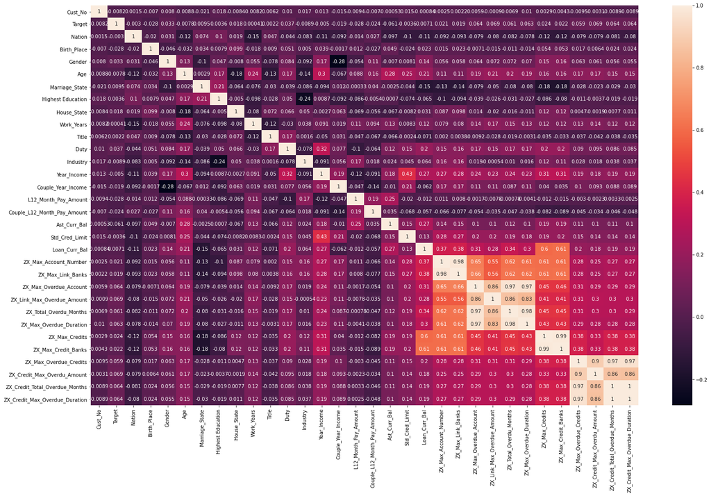

```python
plt.figure(figsize=(25, 15))
sns.heatmap(corr_matrix, annot= True)
```

### 步骤5 存储相关性过高的特征对,对于相关性过高的的特征，删除其中一个

```python
cols_pair_to_drop = []
for index_ in corr_matrix.index:
    for col_ in corr_matrix.columns:
        if corr_matrix.loc[index_,col_] >= 0.8 and index_!=col_ and (col_,index_) not in cols_pair_to_drop:
            cols_pair_to_drop.append((index_,col_))
# print(cols_pair_to_drop)
```

```python
cols_to_drop = np.unique([col[1] for col in cols_pair_to_drop])  #对于一维数组或者列表，unique函数去除其中重复的元素，并按元素由大到小返回一个新的无元素重复的元组或者列表
df.drop(cols_to_drop,axis=1,inplace=True)
df.head()
```

```python
df_missing_stat = pd.DataFrame(df.isnull().sum()/df.shape[0],columns=['missing_rate']).reset_index()
df_missing_stat.sort_values(by='missing_rate',ascending=False)[:15]
```

|  | index | missing_rate |
| --- | --- | --- |
| 16 | Couple_Year_Income | 0.689260 |
| 18 | Couple_L12_Month_Pay_Amount | 0.689260 |
| 10 | Unit_Kind | 0.621634 |
| 11 | Title | 0.571804 |
| 14 | Industry | 0.564222 |
| 12 | Occupation | 0.555091 |
| 8 | House_State | 0.397864 |
| 2 | Nation | 0.330703 |
| 6 | Marriage_State | 0.309037 |
| 7 | Highest Education | 0.299133 |
| 13 | Duty | 0.119003 |
| 21 | Loan_Curr_Bal | 0.000000 |
| 22 | ZX_Max_Account_Number | 0.000000 |
| 23 | ZX_Max_Overdue_Account | 0.000000 |
| 24 | ZX_Max_Credits | 0.000000 |

可以看出缺失率最高的是Couple_Year_Income、Couple_L12_Month_Pay_Amount、Unit_Kind、Title、Industry和Occupation ，缺失率都超过了50%。其中，Couple_Year_Income和Couple_L12_Month_Pay_Amount是数值型变量；而Unit_Kind、Title、Industry和Occupation是名义型变量。

### 步骤7 可视化：针对Couple_Year_Income和Couple_L12_Month_Pay_Amount制作箱型图来判定下如何填充。

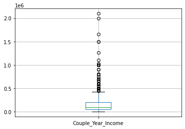

```python
df.boxplot(column=['Couple_Year_Income'])
```

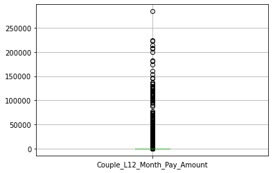

```python
df.boxplot(column=['Couple_L12_Month_Pay_Amount'])
```

从上面箱图可以看出Couple_Year_Income和Couple_L12_Month_Pay_Amount异常值比例都不低，且缺失率很高，可以在删除带有异常值的样本的基础上，一般有两种选择：尝试用中位数（对数值型变量常用且在该业务场景下，使用中位数也符合实际的分布）来填充缺失值；或者直接删除。本实验尝试第一种。